# Bellabeat Case Study

Lidiya Arsova

2025-04-13

## Ask

Bellabeat is a high-tech wellness company that manufactures health-focused smart devices for women. The goal of this project is to analyze Fitbit data and uncover user trends that Bellabeat can use to inform its marketing strategy.

## Prepare

We are working with public Fitbit data collected from 30 users over two months, shared under a public domain license via Kaggle and Zenodo.

We are using two daily activity files — one from each month — and will combine them.

```r
daily1 <- read_csv("dailyActivity_merged.csv")
daily2 <- read_csv("dailyActivity_merged2.csv")
```

## Process

Here, we combine the two datasets, remove any duplicates, and convert the activity date column into proper Date format.

```r
daily_full <- bind_rows(daily1, daily2) %>%
  distinct() %>%
  mutate(ActivityDate = mdy(ActivityDate))
```

## Analyze

We calculate summary statistics to understand users’ daily activity patterns.

```r
daily_full %>%
  summarise(
    avg_steps = mean(TotalSteps, na.rm = TRUE),
    avg_calories = mean(Calories, na.rm = TRUE),
    avg_very_active = mean(VeryActiveMinutes, na.rm = TRUE),
    avg_lightly_active = mean(LightlyActiveMinutes, na.rm = TRUE),
    avg_sedentary = mean(SedentaryMinutes, na.rm = TRUE)
  )
```

```
## # A tibble: 1 × 5
##   avg_steps avg_calories avg_very_active avg_lightly_active avg_sedentary
##       <dbl>        <dbl>           <dbl>              <dbl>         <dbl>
## 1     7281.        2266.            19.7               185.          993.
```

We also explore how different activities correlate with calories burned.

```r
cor_data <- daily_full %>%
  select(TotalSteps, TotalDistance, VeryActiveMinutes, FairlyActiveMinutes,
         LightlyActiveMinutes, SedentaryMinutes, Calories)

cor(cor_data, use = "complete.obs")
```

```
##                      TotalSteps TotalDistance VeryActiveMinutes
## TotalSteps            1.0000000     0.9859539         0.6765583
## TotalDistance         0.9859539     1.0000000         0.6911431
## VeryActiveMinutes     0.6765583     0.6911431         1.0000000
## FairlyActiveMinutes   0.3591856     0.3380976         0.2341731
## LightlyActiveMinutes  0.6040972     0.5553730         0.1047707
## SedentaryMinutes     -0.3110263    -0.2771641        -0.1678437
## Calories              0.5901599     0.6353040         0.5820275
##                      FairlyActiveMinutes LightlyActiveMinutes SedentaryMinutes
## TotalSteps                     0.3591856            0.6040972      -0.31102626
## TotalDistance                  0.3380976            0.5553730      -0.27716405
## VeryActiveMinutes              0.2341731            0.1047707      -0.16784374
## FairlyActiveMinutes            1.0000000            0.1191759      -0.18504495
## LightlyActiveMinutes           0.1191759            1.0000000      -0.41933197
## SedentaryMinutes              -0.1850449           -0.4193320       1.00000000
## Calories                       0.3074824            0.3257006      -0.06192441
##                         Calories
## TotalSteps            0.59015995
## TotalDistance         0.63530399
## VeryActiveMinutes     0.58202752
## FairlyActiveMinutes   0.30748240
## LightlyActiveMinutes  0.32570064
## SedentaryMinutes     -0.06192441
## Calories              1.00000000
```

## Share

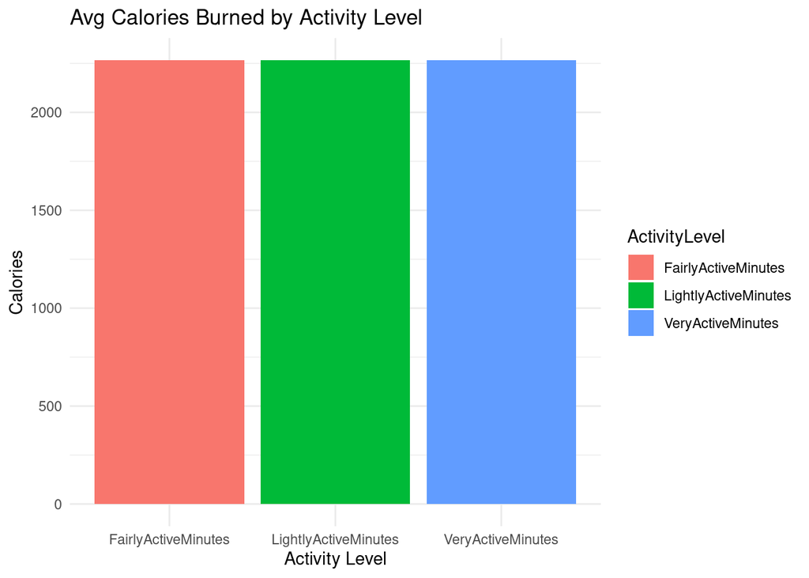

```r
daily_full %>%
  pivot_longer(cols = c(VeryActiveMinutes, FairlyActiveMinutes, LightlyActiveMinutes),
               names_to = "ActivityLevel", values_to = "Minutes") %>%
  group_by(ActivityLevel) %>%
  summarise(AvgCalories = mean(Calories, na.rm = TRUE)) %>%
  ggplot(aes(x = ActivityLevel, y = AvgCalories, fill = ActivityLevel)) +
  geom_col() +
  labs(title = "Avg Calories Burned by Activity Level", y = "Calories", x = "Activity Level") +
  theme_minimal()
```

### Average Steps by Weekday

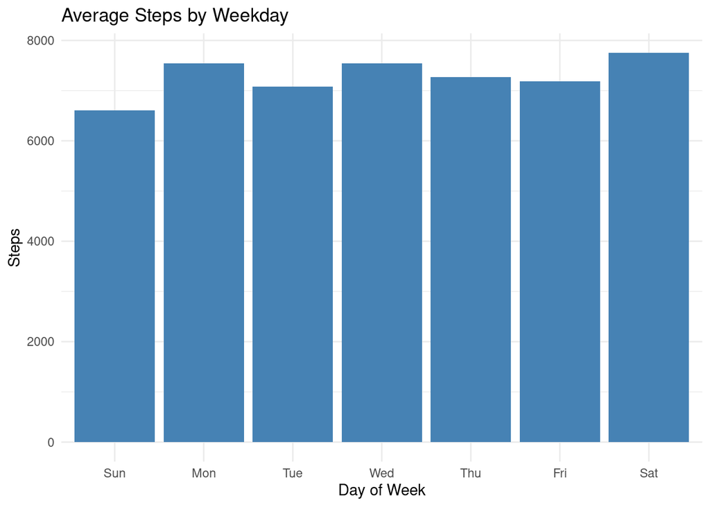

```r
daily_full %>%
  mutate(Weekday = wday(ActivityDate, label = TRUE)) %>%
  group_by(Weekday) %>%
  summarise(AverageSteps = mean(TotalSteps, na.rm = TRUE)) %>%
  ggplot(aes(x = Weekday, y = AverageSteps)) +
  geom_col(fill = "steelblue") +
  labs(title = "Average Steps by Weekday", x = "Day of Week", y = "Steps") +
  theme_minimal()
```

## Act

Based on this analysis, Bellabeat could take the following actions:

Combat Sedentary Behavior: Sedentary minutes are still high. Bellabeat can add movement reminders or gentle nudge notifications via smart devices.

## Conclusion

This project explored user activity data to generate business insights for Bellabeat. Using R and tidyverse, we cleaned and analyzed the data, created visualizations, and delivered actionable recommendations for smarter engagement strategies.